# A Look at the Endangered & Threatened Animals Dataset

Ana De Las Alas, Samuel Lee, Ryan Leung, Joshua Lansing

May 24, 2019

## Introduction

Our team is focusing on data about *endangered and threatened* species in the U.S. Our dataset was taken from the [Environmental Convervation Online System](https://ecos.fws.gov/ecp/report/table/critical-habitat.html?fbclid=IwAR34iloupBtcBAHfH7t8uU0WqRWJyGDKggJShn-J1mSbNVl_Zf_7qYP8kFI). The dataset includes data about specific endangered species and their respective attributes, such as the **region** of the U.S. they are found in, their **species group**, and their **critical habitat type**. With this domain, we can investigate questions like which species group contains the most endangered species, which region is likely to contain certain species groups, and what are the patterns in how many acres are allotted to create critical habitats for these species. The following report will highlight summary information about the dataset as well as three visualizations that convey key points about the data.

## Summary Information

Within the dataset, there are 657 total **endangered** species and 187 total **threatened** species documented. The percentage of species that are endangered is 77.84%. Our dataset shows which *species group* each species belongs to. Based on our calculations, we found that there were 40 mammals documented in the dataset, which means that 4.74% of the species from the data are mammals. The organization separated the U.S. into 9 regions so that readers can better understand where each species in the dataset comes from. This information helps our team recognize that there are more endangered species than threatened species, that mammals make up a small percentage of endangered species, and that the location of the species is dependent on region rather than state or city.

## Aggregate Table

```
## # A tibble: 9 x 2
##   `US Region`        `Number of Endangered/Threatened Species`
##   <chr>                                                  <int>
## 1 Water (Any Region)                                        13
## 2 Pacific                                                  157
## 3 Southwest                                                 78
## 4 Midwest                                                   12
## 5 Southeast                                                117
## 6 Northeast                                                  9
## 7 Mountain-Prairie                                          27
## 8 Alaska Region                                              4
## 9 Pacific Southwest                                        134
```

## Chart One: Boxplot

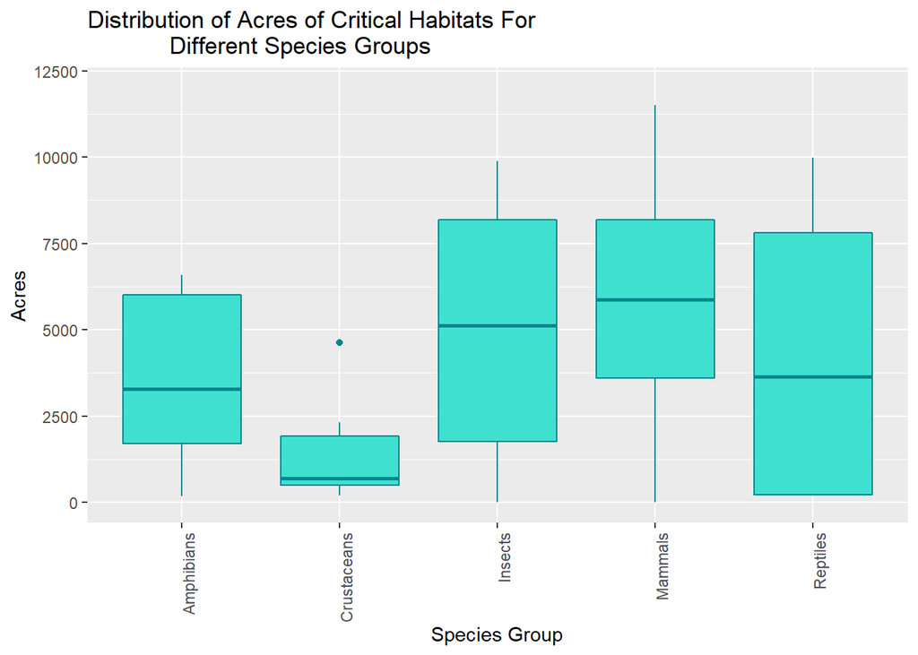

## Chart Two: Bar Graph

This chart was made to show the contrast of *endangered species* in different regions. We decided to use a bar graph for this because it would help us focus in on particularly the endangered species and would help us easily see the difference in quantity of endangered species according to region. **Region 1** has the most amount of endangered species, while **Region 3** has the least amount. **Region 4** has a similar amount as **Region 8** both under *100 species*.

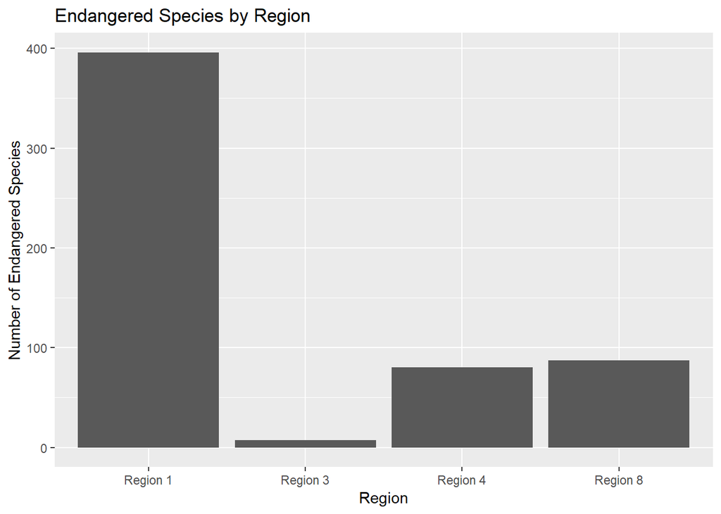

## Chart Three: Lollipop Graph

The purpose of this chart is to display the number of endangered and threatened species within each major U.S. region. From the chart, it can be seen that the **West Coast** has the most number of endangered and threatened, whereas the **East Coast** has the least.

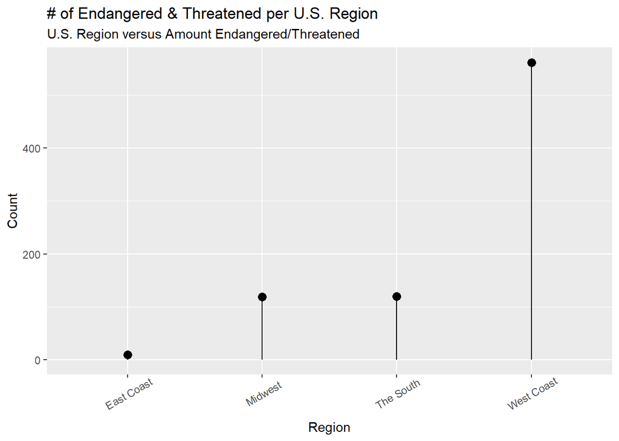